# Targeted cluster analysis

**Product**: ozempic  
**Period**: [2023-03-31,2024-03-31]  
**Cases meeting one of the condition on reported event(s)**:  
**PT**: allodynia  
**FAERS Data Lock Point**: Data contains FAERS reports processed as of 2024Q1.  
**User**:  
**DateTime**: 2024-09-15 21:24:22

# Objective

Assess quantitatively if there is an ‘unexpectedly raised rates’ (further referred as ‘cluster’) of cases presenting one of events selected above post exposure to ozempic during the period [2023-03-31,2024-03-31] within the FAERS spontaneous report database.

# Method

For cluster monitoring, a quantitative method that screens the FAERS spontaneous report database has been implemented. For every event, the following table is provided:

- ‘Nb in Period’: the number of reports for that event with initial receipt date by Company within the interval selected by the user (by default the interval is selected for defining the period)
- ‘Nb in Total’: the total number of reports for that event
- ‘Percentage’: the percentage of reports that are falling in the interval compared to the total number of reports for the selected term(s)
- ‘99% LL CI’: the lower limit of the 99% confidence interval around the %
- ‘99% UL CI’: the upper limit of the 99% confidence interval around the %
- ‘Expected Percentage’ which is percentage of reports (across all events) that are falling in the interval compared to the total number of reports
- ‘Flag cluster’: the field indicates if there is a cluster for that event for the period selected by the user.

# Results

| Drug | Event | Nb in Total | Nb in Period | Percentage | 99% LL CI | 99% UL CI | Flag cluster | Expected Percentage |
| --- | --- | --- | --- | --- | --- | --- | --- | --- |
| ozempic | allodynia | 30 | 25 | 83.3 | 59.6 | 96.2 | Yes | 34.9 |

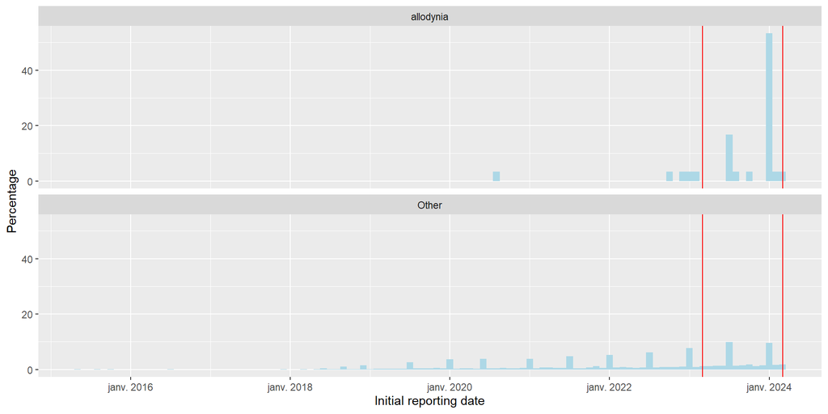

Distribution of the initial reporting date of reports

# Conclusion

Among the MedDRA PT selected in [PT: allodynia], the following MedDRA PTs were flagged as significant clusters (at 99% confidence level) in the interval [2023-03-31,2024-03-31]:

- allodynia.